# Hypothesis Testing for Benchmarking

#### (d) Apply the `$aggregate()` function to the `mlr3` benchmark object and compare the ranks of both algorithms on all tasks.

```r
aggr = bmr$aggregate()
aggr = aggr %>%
  mutate(learner_id = replace(learner_id, learner_id == "encode.classif.ranger", "ranger")) %>%
  mutate(learner_id = replace(learner_id, learner_id == "encode.classif.rpart", "rpart"))

ranktable_wide_rpart_ranger = aggr %>%
  group_by(task_id) %>%
  mutate(rank_on_task = rank(classif.ce)) %>%
  mutate(ce_rank = rank_on_task) %>%
  select(c(task_id, learner_id, ce_rank)) %>%
  pivot_wider(names_from = learner_id, values_from = ce_rank)

ranktable_wide_rpart_ranger
```

```
## # A tibble: 20 × 3
## # Groups:   task_id [20]
##    task_id          rpart ranger
##    <chr>            <dbl>  <dbl>
##  1 monks-problems-1     2      1
##  2 monks-problems-3     1      2
##  3 space_ga             2      1
##  4 fri_c1_1000_5        2      1
##  5 fri_c3_500_5         2      1
##  6 pm10                 2      1
##  7 strikes              2      1
##  8 fri_c0_1000_5        2      1
##  9 delta_ailerons       2      1
## 10 kin8nm               2      1
## 11 puma8NH              2      1
## 12 delta_elevators      2      1
## 13 stock                2      1
## 14 fri_c1_500_5         2      1
## 15 pollen               2      1
## 16 fri_c0_500_5         2      1
## 17 no2                  2      1
## 18 balance-scale        2      1
## 19 threeOf9             2      1
## 20 phoneme              2      1
```

#### (e) Run the Wilcoxon signed rank test using the ranks you computed:

```r
r_plus = sum(as.numeric(ranktable_wide_rpart_ranger$rpart == 1))
r_minus = sum(as.numeric(ranktable_wide_rpart_ranger$rpart == 2))
M = nrow(ranktable_wide_rpart_ranger)
wilcoxon = (min(r_plus, r_minus) - ((1 / 4) * M * (M + 1))) / sqrt((1 / 24) * M * (M + 1) * (2 * M + 1))
wilcoxon
```

```
## [1] -3.882598
```

## Question 3: Multiple Algorithms on Multiple Data Sets

#### (a) Let us now compare more algorithms on each task. Rerun the benchmark with the learners “classif.featureless”, “classif.cv_glmnet”, “classif.rpart”, “classif.ranger”, “classif.kknn”, and “classif.svm”. As before, use one-hot encodings.

```r
learners = lapply(c("classif.featureless",  "classif.cv_glmnet", "classif.rpart", "classif.ranger", "classif.kknn", "classif.svm"), lrn)
poe = po("encode", method = "one-hot")
learners = lapply(learners, FUN = function(x) {po("encode") %>>% x})

resamplings = rsmp("cv", folds = 3)
design = benchmark_grid(tasklist, learners, resamplings)

set.seed(123)
bmr = benchmark(design)

aggr = bmr$aggregate()
aggr = aggr %>%
  mutate(learner_id = replace(learner_id, learner_id == "encode.classif.featureless", "featureless")) %>%
  mutate(learner_id = replace(learner_id, learner_id == "encode.classif.ranger", "ranger")) %>%
  mutate(learner_id = replace(learner_id, learner_id == "encode.classif.kknn", "kknn")) %>%
  mutate(learner_id = replace(learner_id, learner_id == "encode.classif.rpart", "rpart")) %>%
  mutate(learner_id = replace(learner_id, learner_id == "encode.classif.svm", "svm")) %>%
  mutate(learner_id = replace(learner_id, learner_id == "encode.classif.cv_glmnet", "cv_glmnet"))
```

#### (b) Given multiple algorithms on multiple data sets, we have to use an omnibus test such as the Friedman test. Compute a rank table that tells you the rank of each algorithm for each task. Then, compute the average rank of each algorithm and proceed with the computation of the Friedman statistic.

```r
ranktable = aggr %>%
  group_by(task_id) %>%
  mutate(rank_on_task = rank(classif.ce)) %>%
  mutate(ce_rank = paste(round(classif.ce, 4), " (", rank_on_task, ")", sep =  ""))

averageranks = ranktable %>%
  group_by(learner_id) %>%
  summarize(average_rank_on_task = mean(rank_on_task))

averageranks
```

```
## # A tibble: 6 × 2
##   learner_id  average_rank_on_task
##   <chr>                      <dbl>
## 1 cv_glmnet                   4.05
## 2 featureless                 5.8
## 3 kknn                        3.55
## 4 ranger                      1.8
## 5 rpart                       3.7
## 6 svm                         2.1
```

```r
meanrank = (1 / nrow(ranktable)) * sum(ranktable$rank_on_task)
meanrank
```

```
## [1] 3.5
```

```r
sstotal = length(tasklist) *
  sum((averageranks$average_rank_on_task- meanrank)^2)
sstotal
```

```
## [1] 209.7
```

```r
sserror = (1 / (length(tasklist) * (length(learners) - 1))) * sum((ranktable$rank_on_task - meanrank)^2)
sserror
```

```
## [1] 3.47
```

```r
friedmanstat = sstotal / sserror
friedmanstat
```

```
## [1] 60.43228
```

#### (c) Run a sanity check with the `friedman.test` function implemented in the `stats` package.

```r
ce_table_wide = ranktable %>%
  select(c(task_id, learner_id, classif.ce)) %>%
  pivot_wider(names_from = learner_id, values_from = classif.ce) %>%
  ungroup() %>%
  select(-task_id) %>%
  as.matrix()
ce_table_wide
```

```
##       featureless  cv_glmnet      rpart      ranger       kknn        svm
##  [1,]   0.5323452 0.25359876 0.16202654 0.005395718 0.02338467 0.00000000
##  [2,]   0.4945652 0.03610458 0.01083040 0.010830396 0.01625539 0.01083040
##  [3,]   0.5094933 0.16253490 0.21531905 0.164790878 0.18602982 0.15352620
##  [4,]   0.4570139 0.37700275 0.14498031 0.088001175 0.11200722 0.08700916
##  [5,]   0.5301085 0.36398288 0.14395306 0.109960801 0.11599692 0.11400091
##  [6,]   0.5120362 0.51203617 0.41194719 0.407931126 0.44608374 0.48792776
##  [7,]   0.5088103 0.41115354 0.08645412 0.043230892 0.12638020 0.27839376
##  [8,]   0.5360270 0.15502029 0.18601536 0.123012234 0.14100628 0.10702319
##  [9,]   0.4693501 0.06059780 0.06410438 0.056249283 0.06396368 0.05891453
## [10,]   0.4912106 0.27050748 0.27111753 0.163329546 0.16528284 0.11547721
## [11,]   0.5023183 0.17334015 0.19177163 0.167846536 0.22338743 0.17150873
## [12,]   0.4990020 0.11841993 0.13113426 0.118629337 0.13869874 0.11726385
## [13,]   0.4862902 0.17893889 0.06421621 0.035795099 0.03685661 0.05790374
## [14,]   0.4660198 0.33409085 0.14390496 0.117944833 0.16201332 0.15000120
## [15,]   0.5028583 0.50285829 0.49168372 0.511956223 0.51221826 0.50988121
## [16,]   0.5240603 0.17814972 0.18408965 0.134117308 0.17614169 0.12612125
## [17,]   0.5199962 0.43410769 0.40398721 0.379914869 0.42196330 0.38391891
## [18,]   0.4608330 0.04800791 0.16481107 0.107126426 0.11676481 0.05276193
## [19,]   0.4648091 0.19721362 0.15023506 0.005870886 0.13272560 0.01169591
## [20,]   0.5053602 0.26450840 0.20964894 0.110974694 0.13556397 0.16298908
```

```r
friedman.test(ce_table_wide)
```

```
##
##  Friedman rank sum test
##
## data:  ce_table_wide
## Friedman chi-squared = 60.432, df = 5, p-value = 0.000000000009895
```

#### (d) Use the function `frdAllPairsNemenyiTest` from the `PMCMRplus` package to run all pairwise Nemenyi tests.

```r
library(PMCMRplus)
rownames(ce_table_wide) = LETTERS[1:nrow(ce_table_wide)]
nemenyi_test = frdAllPairsNemenyiTest(y = ce_table_wide)
nemenyi_test$statistic
```

```
##           featureless cv_glmnet     rpart    ranger     kknn
## cv_glmnet    4.183300        NA        NA        NA       NA
## rpart        5.019960  0.836660        NA        NA       NA
## ranger       9.561829  5.378529 4.5418687        NA       NA
## kknn         5.378529  1.195229 0.3585686 4.1833001       NA
## svm          8.844692  4.661392 3.8247315 0.7171372 3.466163
```

```r
nemenyi_test$p.value
```

```
##                  featureless   cv_glmnet      rpart     ranger      kknn
## cv_glmnet 0.0365739599769087          NA         NA         NA        NA
## rpart     0.0051776013186932 0.991625658         NA         NA        NA
## ranger    0.0000000002052161 0.001982226 0.01663900         NA        NA
## kknn      0.0019822260320472 0.958997390 0.99985842 0.03657396        NA
## svm       0.0000000059902699 0.012581846 0.07430212 0.99592480 0.1390402
```

#### (e) Manually compute the critical difference for rpart and ranger.

Hint: Use the `qtukey` function.

```r
mean_diff_rpart_ranger = averageranks[averageranks$learner_id == "rpart", 2] - averageranks[averageranks$learner_id == "ranger", 2]
# # critical mean rank difference
crit_value_mean_rank_diff = (qtukey(p = 0.05, df = Inf, nmeans = 6, lower.tail = FALSE) / sqrt(2)) * (sqrt((6 * (6 + 1)) / (6 * 16)))

mean_diff_rpart_ranger > crit_value_mean_rank_diff
```

```
##      average_rank_on_task
## [1,]                 TRUE
```

```r
# reject H_0!
```

#### (f) Manually compare `rpart` and `ranger` with the Bonferroni-Dunn test.

Hint: The probability of observing the test statistic under the null hypothesis is given by `pnorm(<...>, 0, 1, lower.tail = FALSE)`.

```r
# bonferroni dunn test
dunn_stat = (abs(mean_diff_rpart_ranger$average_rank_on_task) / sqrt((6 * 7) / 6 * 16))
# prob of observing dunn statistic under h0:
pnorm(dunn_stat, 0, 1, lower.tail = FALSE)
```

```
## [1] 0.4287596
```

```r
# do not reject H_0
```

#### (g) Compute a criticial difference plot with `mlr3`.

```r
# sanity check with mlr3
library(mlr3benchmark)
benchmark_aggr = as_benchmark_aggr(bmr, measures = msr("classif.ce"))
benchmark_aggr$friedman_test()
```

```
##
##  Friedman rank sum test
##
## data:  ce and learner_id and task_id
## Friedman chi-squared = 60.432, df = 5, p-value = 0.000000000009895
```

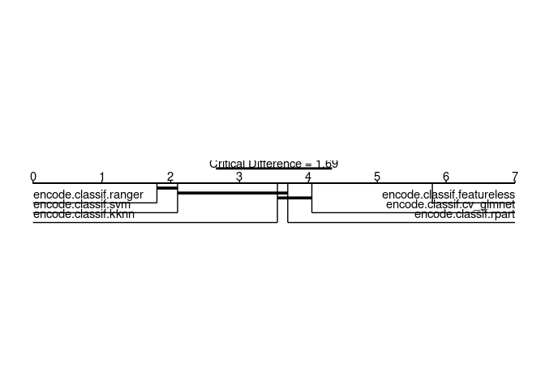

```r
cd_plot = autoplot(benchmark_aggr, type = "cd", meas = "ce", minimize = TRUE)
cd_plot
```